# Фенология копепод

24 февраля 2019 г

# Часть 1. Как описывать фенологию?

# Данные

После пересчета, для каждого вида были отобраны только данные по обилию копеподитов.

# Фенологическая матрица

Для описания фенологических событий была создана матрица, содержащая в себе даты (количество дней от 1 января соответствующего года) следующих ключевых событий для каждого вида:

1. Наблюдаемый пик численности в точке наблюдения
2. Появление в точке наблюдения
3. Исчезновение из точки наблюдения
4. Ожидаемый пик численности в точке наблюдения.

Первый показатель вычислялся, как дата, когда физически наблюдалось самое высокое значение численности (в тех, редких, ситуациях, когда наблюдалось два абсолютно равных по высоте пика, бралась средняя дата между ними).

Три оставшихся показателя были вычислены в соответствии со следующим алгоритмом.

**Шаг 1.** Для каждого года, для каждого вида была построена кумулята, отражающая накопленное количество особей, приходящееся на данную дату.

**Шаг 2.** Для полученного ряда чисел были подобраны параметры логистической кривой, которая наилучшим образом вписывается в наблюдаемый ряд.

Вот пример такой кумуляты для в 2013 г. для *Oithona*.

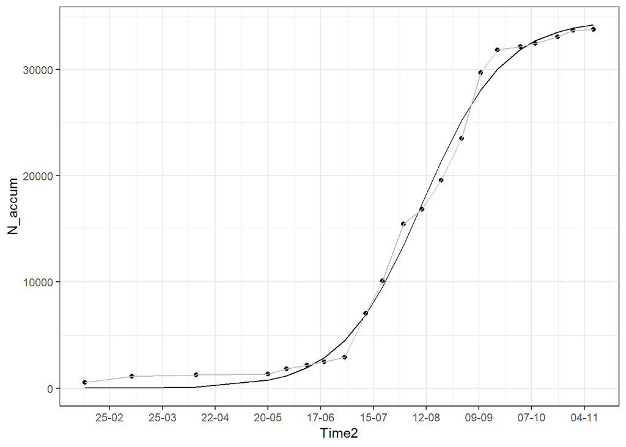

В тот же год для *Temora*

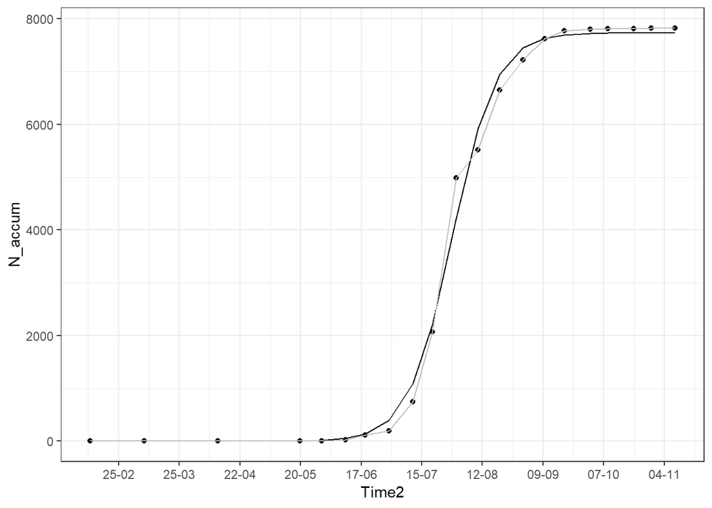

В тот же год для *Centropages*

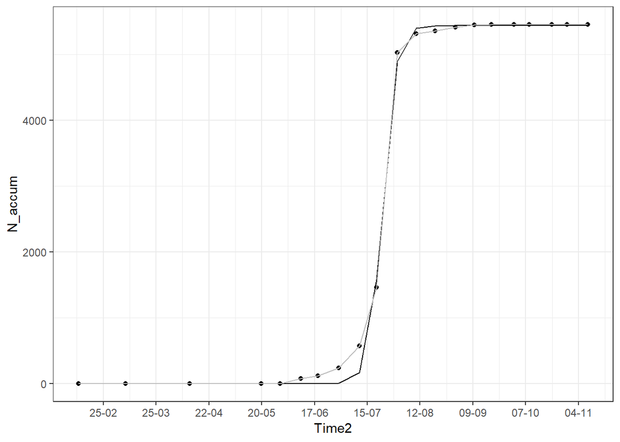

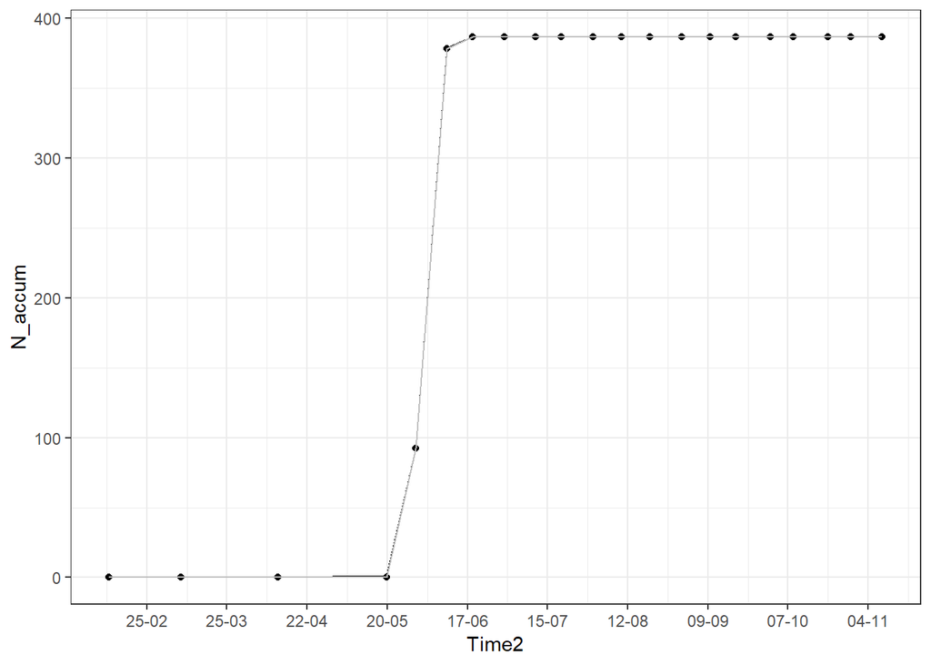

Собственно почти все неудачи подбора логистической кривой были связаны с *Calanus*. Это связано с узкими и острыми пиками численности, характерными для данного вида. На кумуляте это выглядит, как очень резкая зона перегиба.

Единственный случай, когда не удалось подобрать логистическую кривую для других видов – это 2014 год у *Oithona*. Вот ее кумулята.

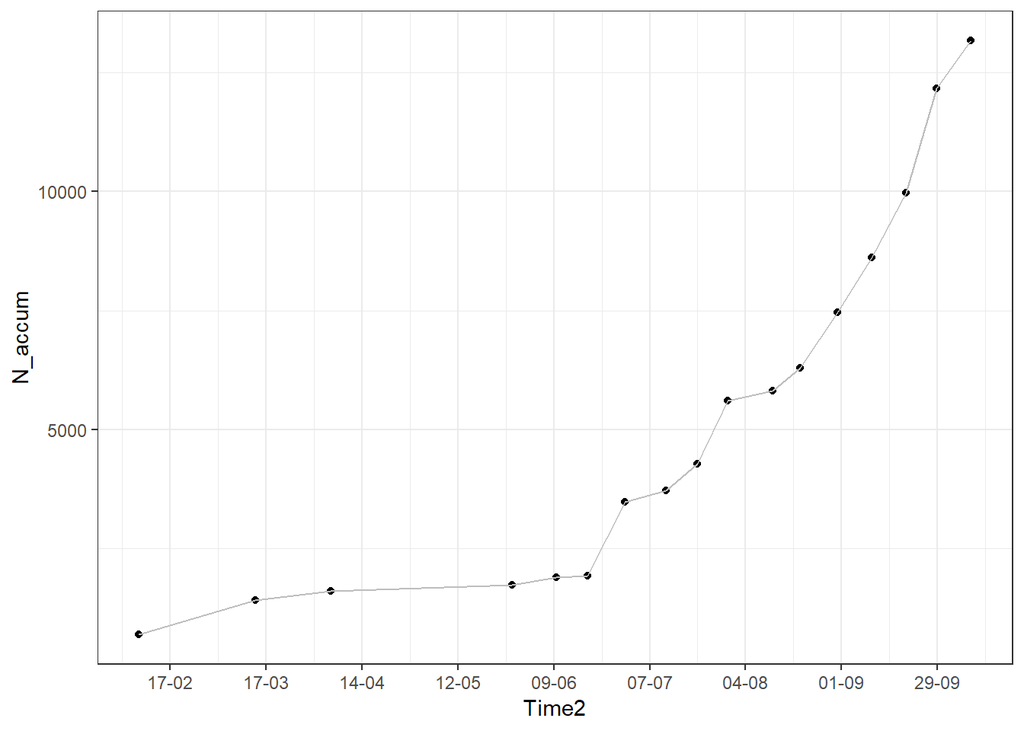

Здесь причина неудачи с подбором логистической кривой заключается в том, что кумулята не достигла максимума за весь период наблюдений. Если не придумаем ничего интереснее, то этот год, вероятно, надо исключить.

**Шаг 3.** Имея в руках параметры логистической кривой, мы можем вычислить все интересующие нас параметры. В качестве начала появления вида в точке наблюдений берем дату, когда логистическая кривая достигает 15% от ее максимума (точнее значения асимптоты). В качестве окончания периода регистрации вида в точке наблюдения – 85% от максимума логистической кривой. Ожидаемый пик численности - это точка перегиба логистической кривой.

**Шаг 4.** Для *Calanus*, в случаях, когда наблюдались острые и сжатые пики, все события (1. Наблюдаемый пик численности в точке наблюдения; 2. Появление в точке наблюдения; 3. Исчезновение из точки наблюдения; 4. Ожидаемый пик численности в точке наблюдения) считались произошедшими одновременно. Их дата считалась совпадающей с датой наблюдаемого пика численности.

**Шаг 5.** Все параметры были сведены в фенологическую матрицу.

Вот матрицы для каждого из видов.

*Calanus*. Там, где стоит NA - это случаи, когда не удалось подобрать параметры логистической кривой.

| Year | Peak | Begin | Meadle | End |
| --- | --- | --- | --- | --- |
| 1961 | 165.0 | NA | NA | NA |
| 1962 | 161.0 | NA | NA | NA |
| 1963 | 162.0 | NA | NA | NA |
| 1964 | 171.0 | 164 | 169 | 175 |
| 1965 | 160.0 | 153 | 160 | 167 |
| 1966 | 200.0 | NA | NA | NA |
| 1967 | 160.0 | 148 | 152 | 156 |
| 1968 | 161.0 | 147 | 156 | 165 |
| 1969 | 181.0 | NA | NA | NA |
| 1970 | 171.0 | 162 | 165 | 168 |
| 1971 | 190.0 | 179 | 182 | 185 |
| 1972 | 247.8 | NA | NA | NA |
| 1973 | 150.0 | 143 | 148 | 153 |
| 1974 | 160.0 | NA | NA | NA |
| 1975 | 151.0 | 146 | 150 | 154 |
| 1976 | 152.0 | 148 | 152 | 156 |
| 1977 | 163.0 | NA | NA | NA |
| 1978 | 161.0 | 155 | 159 | 163 |
| 1979 | 171.0 | NA | NA | NA |
| 1980 | 162.0 | 157 | 159 | 162 |
| 1981 | 160.0 | 146 | 156 | 165 |
| 1982 | 149.0 | 138 | 151 | 164 |
| 1983 | 170.0 | 150 | 159 | 168 |
| 1984 | 151.0 | 147 | 150 | 153 |
| 1985 | 170.0 | 165 | 169 | 173 |
| 1986 | 159.0 | 154 | 157 | 159 |
| 1987 | 170.0 | 158 | 165 | 172 |
| 1988 | 154.0 | 146 | 151 | 157 |
| 1989 | 161.0 | 148 | 155 | 161 |
| 1990 | 169.0 | NA | NA | NA |
| 1991 | 170.0 | 165 | 168 | 171 |
| 1992 | 152.0 | 131 | 148 | 164 |
| 1993 | 160.0 | 153 | 157 | 161 |
| 1994 | 170.0 | 158 | 161 | 164 |
| 1995 | 151.0 | 136 | 147 | 157 |
| 1996 | 153.0 | 141 | 154 | 166 |
| 1997 | 180.0 | 170 | 172 | 174 |
| 1998 | 180.0 | 172 | 174 | 176 |
| 1999 | 171.0 | NA | NA | NA |
| 2000 | 161.0 | 148 | 152 | 156 |
| 2001 | 161.0 | 146 | 154 | 162 |
| 2002 | 161.0 | NA | NA | NA |
| 2003 | 150.0 | 144 | 148 | 152 |
| 2004 | 161.0 | 150 | 156 | 162 |
| 2005 | 161.0 | NA | NA | NA |
| 2006 | 160.0 | 149 | 153 | 156 |
| 2007 | 140.0 | 134 | 144 | 154 |
| 2008 | 162.0 | 150 | 155 | 161 |
| 2009 | 170.0 | 155 | 161 | 167 |
| 2010 | 160.0 | NA | NA | NA |
| 2011 | 161.0 | 137 | 148 | 158 |
| 2012 | 151.0 | 146 | 149 | 153 |
| 2013 | 160.0 | 148 | 151 | 155 |
| 2014 | 160.0 | 155 | 159 | 162 |
| 2015 | 160.0 | NA | NA | NA |
| 2016 | 144.0 | 135 | 139 | 144 |
| 2017 | 155.0 | 148 | 157 | 165 |
| 2018 | 139.0 | 137 | 139 | 141 |

*Centropages*.

| Year | Peak | Begin | Meadle | End |
| --- | --- | --- | --- | --- |
| 1961 | 221.0 | 198 | 217 | 237 |
| 1962 | 262.0 | 188 | 230 | 273 |
| 1963 | 221.0 | 211 | 222 | 233 |
| 1964 | 212.0 | 201 | 214 | 227 |
| 1965 | 241.0 | 190 | 219 | 247 |
| 1966 | 252.0 | 238 | 243 | 248 |
| 1967 | 221.0 | 195 | 216 | 236 |
| 1968 | 201.0 | 191 | 211 | 230 |
| 1969 | 241.0 | 228 | 235 | 242 |
| 1970 | 242.0 | 216 | 235 | 255 |
| 1971 | 242.0 | 232 | 238 | 245 |
| 1972 | 222.0 | 201 | 221 | 241 |
| 1973 | 241.0 | 223 | 236 | 250 |
| 1974 | 241.0 | 228 | 236 | 244 |
| 1975 | 221.0 | 199 | 212 | 225 |
| 1976 | 196.5 | 163 | 198 | 233 |
| 1977 | 216.0 | 209 | 216 | 223 |
| 1978 | 242.0 | 207 | 228 | 249 |
| 1979 | 241.0 | 224 | 237 | 251 |
| 1980 | 223.0 | 215 | 225 | 235 |
| 1981 | 242.0 | 223 | 237 | 250 |
| 1982 | 252.0 | 214 | 233 | 252 |
| 1983 | 253.0 | 211 | 240 | 270 |
| 1984 | 253.0 | 229 | 239 | 250 |
| 1985 | 220.0 | 206 | 223 | 241 |
| 1986 | 211.0 | 196 | 213 | 230 |
| 1987 | 230.0 | 213 | 232 | 251 |
| 1988 | 200.0 | 186 | 206 | 225 |
| 1989 | 230.0 | 201 | 216 | 232 |
| 1990 | 231.0 | 212 | 222 | 233 |
| 1991 | 232.0 | 213 | 229 | 245 |
| 1992 | 243.0 | 214 | 235 | 256 |
| 1993 | 232.0 | 200 | 222 | 244 |
| 1994 | 231.0 | 207 | 223 | 240 |
| 1995 | 241.0 | 196 | 224 | 253 |
| 1996 | 253.0 | 225 | 241 | 258 |
| 1997 | 231.0 | 218 | 230 | 242 |
| 1998 | 231.0 | 206 | 226 | 247 |
| 1999 | 241.0 | 205 | 228 | 252 |
| 2000 | 213.0 | 203 | 213 | 223 |
| 2001 | 241.0 | 207 | 222 | 237 |
| 2002 | 231.0 | 199 | 222 | 245 |
| 2003 | 222.0 | 200 | 210 | 220 |
| 2004 | 222.0 | 200 | 216 | 232 |
| 2005 | 231.0 | 203 | 218 | 232 |
| 2006 | 221.0 | 184 | 210 | 235 |
| 2007 | 241.0 | 176 | 213 | 250 |
| 2008 | 172.0 | 155 | 183 | 211 |
| 2009 | 189.0 | 181 | 189 | 198 |
| 2010 | 251.0 | 223 | 241 | 259 |
| 2011 | 221.0 | 204 | 214 | 225 |
| 2012 | 221.0 | 173 | 210 | 248 |
| 2013 | 211.0 | 197 | 203 | 209 |
| 2014 | 231.0 | 199 | 225 | 251 |
| 2015 | 210.0 | 192 | 204 | 217 |
| 2016 | 232.0 | 199 | 221 | 243 |
| 2017 | 233.0 | 190 | 218 | 245 |
| 2018 | 220.0 | 201 | 218 | 235 |

*Temora*.

| Year | Peak | Begin | Meadle | End |
| --- | --- | --- | --- | --- |
| 1961 | 234 | 208 | 227 | 246 |
| 1962 | 246 | 226 | 239 | 251 |
| 1963 | 252 | 217 | 237 | 258 |
| 1964 | 231 | 212 | 226 | 240 |
| 1965 | 241 | 227 | 254 | 280 |
| 1966 | 262 | 239 | 249 | 260 |
| 1967 | 253 | 236 | 246 | 256 |
| 1968 | 253 | 240 | 249 | 258 |
| 1969 | 241 | 232 | 253 | 274 |
| 1970 | 242 | 232 | 252 | 271 |
| 1971 | 242 | 202 | 230 | 259 |
| 1972 | 233 | 219 | 240 | 261 |
| 1973 | 241 | 226 | 248 | 271 |
| 1974 | 231 | 220 | 228 | 235 |
| 1975 | 273 | 222 | 260 | 298 |
| 1976 | 252 | 227 | 243 | 258 |
| 1977 | 231 | 211 | 228 | 245 |
| 1978 | 242 | 223 | 232 | 241 |
| 1979 | 262 | 241 | 252 | 263 |
| 1980 | 223 | 217 | 236 | 255 |
| 1981 | 252 | 224 | 243 | 262 |
| 1982 | 252 | 216 | 242 | 268 |
| 1983 | 253 | 223 | 245 | 266 |
| 1984 | 253 | 232 | 243 | 253 |
| 1985 | 230 | 214 | 233 | 252 |
| 1986 | 252 | 217 | 240 | 262 |
| 1987 | 255 | 235 | 248 | 261 |
| 1988 | 234 | 221 | 240 | 260 |
| 1989 | 230 | 215 | 230 | 246 |
| 1990 | 273 | 216 | 243 | 271 |
| 1991 | 232 | 219 | 228 | 237 |
| 1992 | 253 | 230 | 244 | 258 |
| 1993 | 242 | 229 | 241 | 252 |
| 1994 | 243 | 218 | 233 | 248 |
| 1995 | 253 | 201 | 240 | 279 |
| 1996 | 253 | 224 | 242 | 260 |
| 1997 | 231 | 221 | 236 | 250 |
| 1998 | 241 | 217 | 232 | 247 |
| 1999 | 262 | 221 | 245 | 269 |
| 2000 | 213 | 206 | 231 | 255 |
| 2001 | 232 | 208 | 233 | 258 |
| 2002 | 252 | 233 | 252 | 270 |
| 2003 | 222 | 206 | 230 | 253 |
| 2004 | 222 | 210 | 231 | 252 |
| 2005 | 231 | 204 | 222 | 240 |
| 2006 | 170 | 167 | 212 | 257 |
| 2007 | 241 | 219 | 237 | 256 |
| 2008 | 212 | 182 | 220 | 258 |
| 2009 | 231 | 192 | 213 | 235 |
| 2010 | 251 | 228 | 241 | 254 |
| 2011 | 221 | 202 | 217 | 231 |
| 2012 | 253 | 222 | 242 | 261 |
| 2013 | 211 | 192 | 209 | 226 |
| 2014 | 231 | 198 | 223 | 247 |
| 2015 | 263 | 219 | 241 | 264 |
| 2016 | 232 | 213 | 225 | 237 |
| 2017 | 272 | 210 | 244 | 277 |
| 2018 | 220 | 214 | 234 | 253 |

*Oithona*.

| Year | Peak | Begin | Meadle | End |
| --- | --- | --- | --- | --- |
| 1961 | 316 | 182 | 257 | 332 |
| 1962 | 254 | 185 | 225 | 266 |
| 1963 | 211 | 198 | 208 | 218 |
| 1964 | 273 | 250 | 266 | 281 |
| 1965 | 118 | 131 | 301 | 471 |
| 1966 | 150 | 118 | 208 | 298 |
| 1967 | 211 | 164 | 210 | 256 |
| 1968 | 201 | 192 | 247 | 301 |
| 1969 | 160 | 97 | 195 | 293 |
| 1970 | 190 | 139 | 232 | 325 |
| 1971 | 139 | 83 | 150 | 218 |
| 1972 | 254 | 202 | 249 | 296 |
| 1973 | 282 | 221 | 283 | 344 |
| 1974 | 263 | 171 | 227 | 283 |
| 1975 | 273 | 222 | 280 | 338 |
| 1976 | 222 | 146 | 209 | 272 |
| 1977 | 252 | 186 | 248 | 309 |
| 1978 | 281 | 183 | 248 | 313 |
| 1979 | 220 | 191 | 256 | 320 |
| 1980 | 284 | 155 | 232 | 309 |
| 1981 | 252 | 188 | 235 | 283 |
| 1982 | 221 | 160 | 221 | 282 |
| 1983 | 191 | 149 | 191 | 232 |
| 1984 | 253 | 173 | 248 | 324 |
| 1985 | 251 | 194 | 248 | 301 |
| 1986 | 180 | 135 | 205 | 274 |
| 1987 | 292 | 167 | 291 | 416 |
| 1988 | 74 | 51 | 192 | 332 |
| 1989 | 200 | 170 | 196 | 222 |
| 1990 | 221 | 178 | 236 | 294 |
| 1991 | 149 | 72 | 186 | 299 |
| 1992 | 295 | 197 | 269 | 340 |
| 1993 | 190 | 184 | 230 | 275 |
| 1994 | 263 | 208 | 255 | 303 |
| 1995 | 210 | 175 | 230 | 284 |
| 1996 | 222 | 185 | 240 | 295 |
| 1997 | 318 | 190 | 258 | 325 |
| 1998 | 200 | 184 | 226 | 267 |
| 1999 | 318 | 174 | 272 | 370 |
| 2000 | 192 | 144 | 248 | 352 |
| 2001 | 220 | 175 | 211 | 247 |
| 2002 | 252 | 172 | 257 | 341 |
| 2003 | 190 | 158 | 203 | 248 |
| 2004 | 201 | 154 | 215 | 276 |
| 2005 | 262 | 217 | 268 | 318 |
| 2006 | 317 | 172 | 245 | 318 |
| 2007 | 180 | 158 | 192 | 227 |
| 2008 | 264 | 208 | 265 | 321 |
| 2009 | 200 | 180 | 193 | 206 |
| 2010 | 251 | 184 | 257 | 330 |
| 2011 | 343 | 159 | 249 | 340 |
| 2012 | 253 | 186 | 279 | 371 |
| 2013 | 252 | 183 | 221 | 258 |
| 2014 | 271 | NA | NA | NA |
| 2015 | 210 | 99 | 216 | 334 |
| 2016 | 181 | 134 | 201 | 268 |
| 2017 | 324 | 181 | 274 | 366 |
| 2018 | 131 | 123 | 199 | 274 |

# Визуализация сезонной динамики видов

Ниже на рисунках красная вертикальная линия – наблюдаемый пик, синяя вертикальная линия – пик, вычисленный по логистической кривой. Возможно, что различия в датах этих пиков может характеризовать наличие дополнительных пиков в более ранние или более поздние сроки. Синяя кривая - это просто сглаживающая функция (loess).

## Динамика Calanus

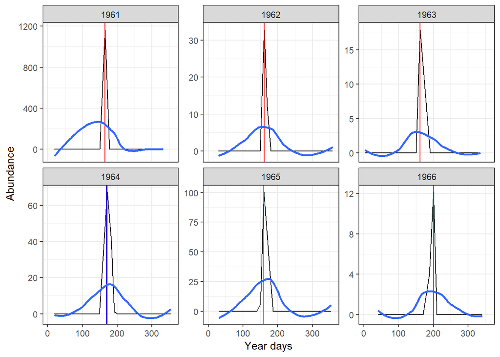

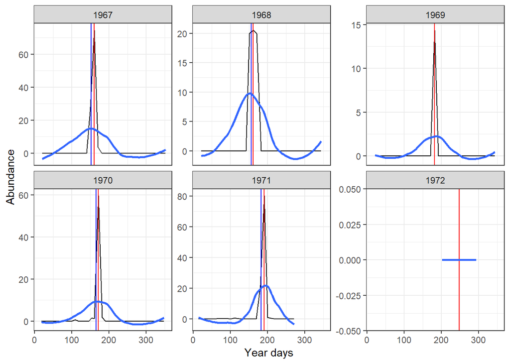

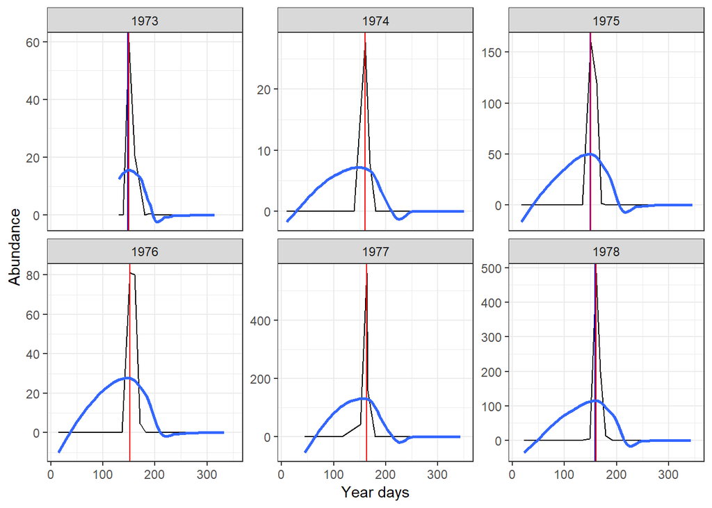

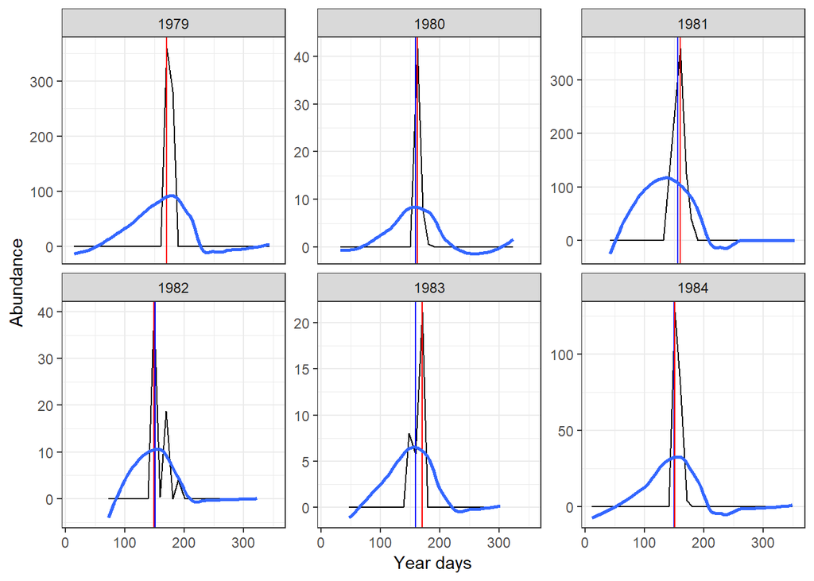

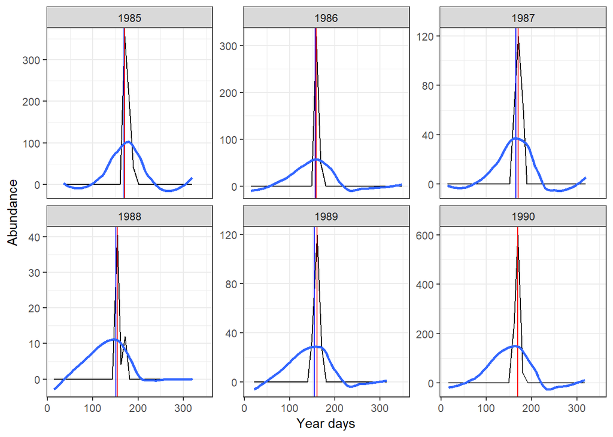

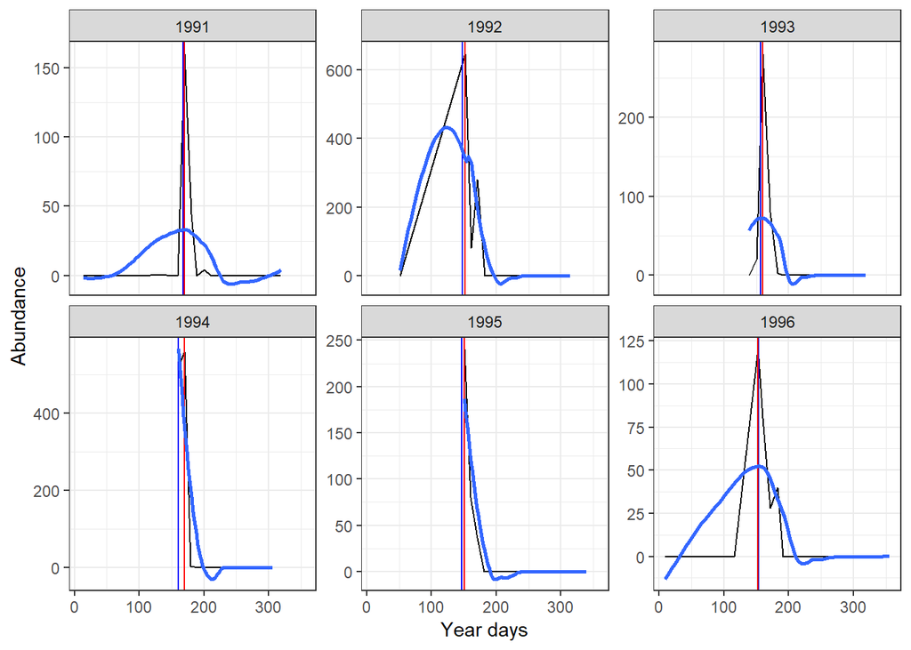

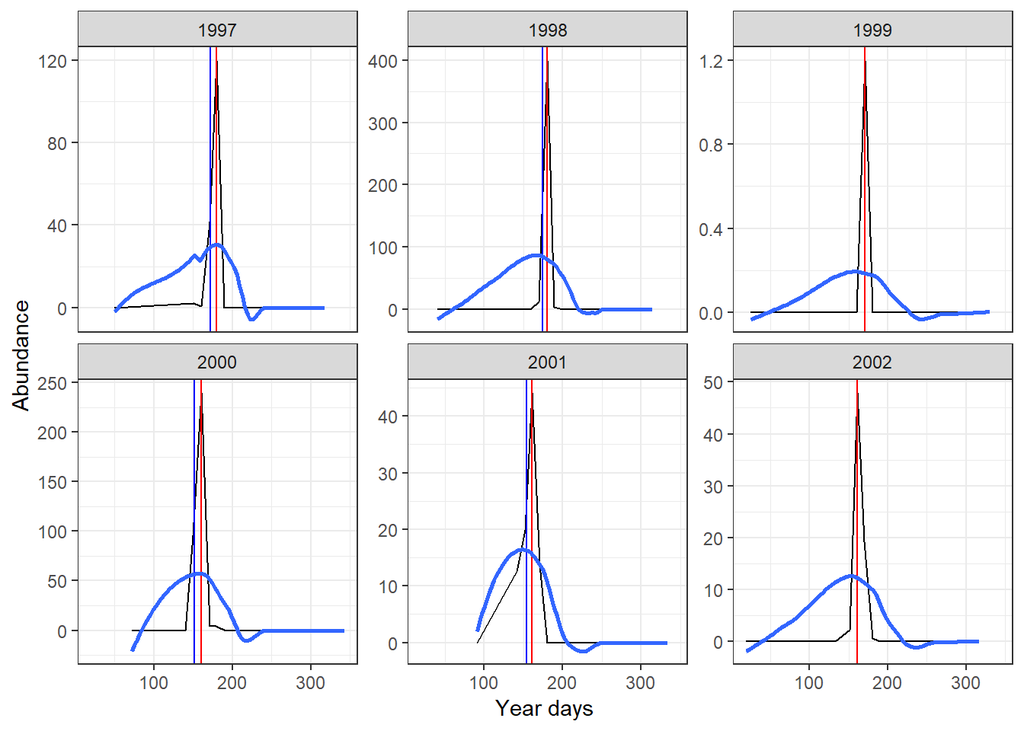

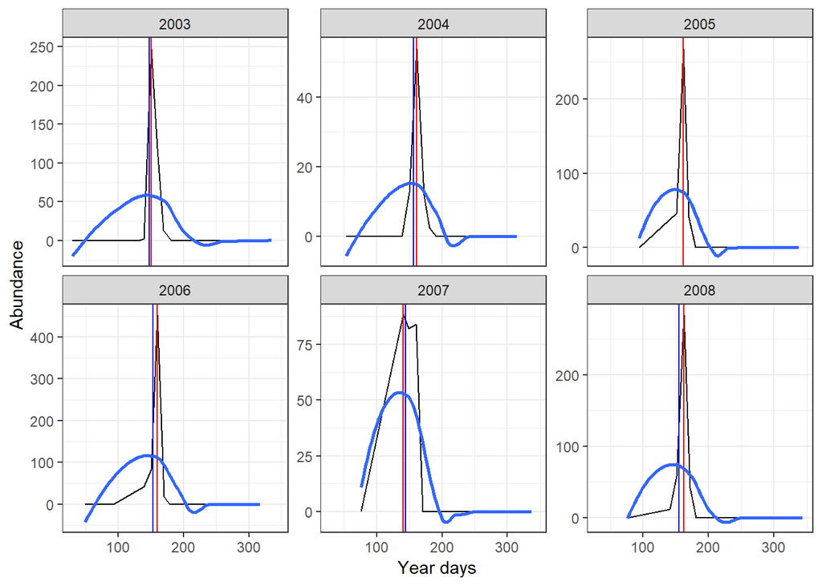

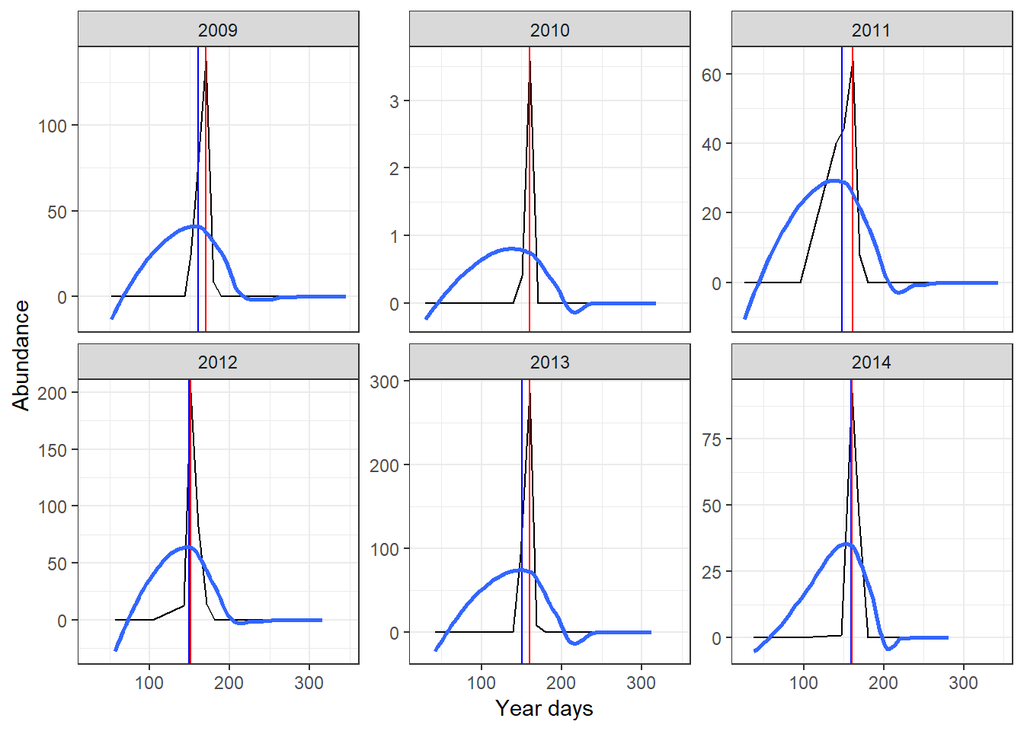

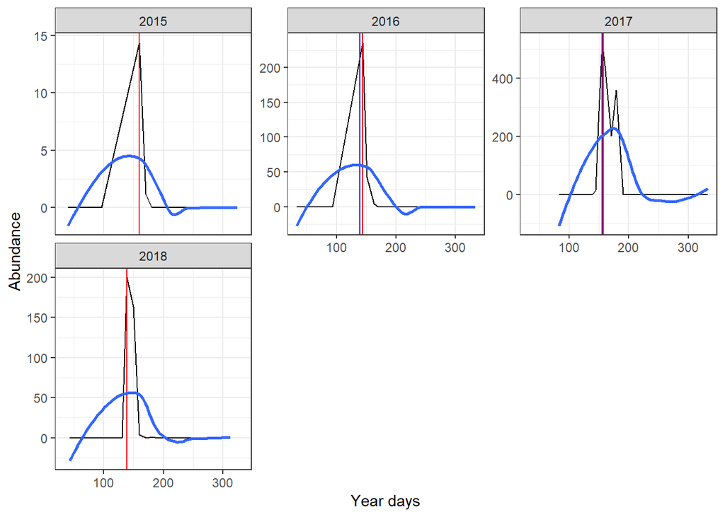

## Динамика Centropages

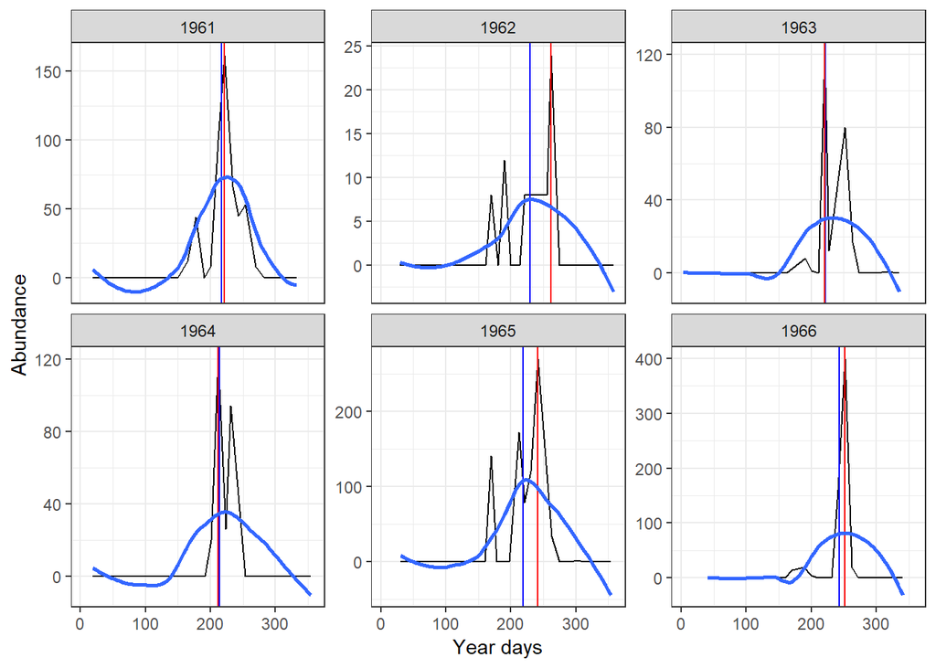

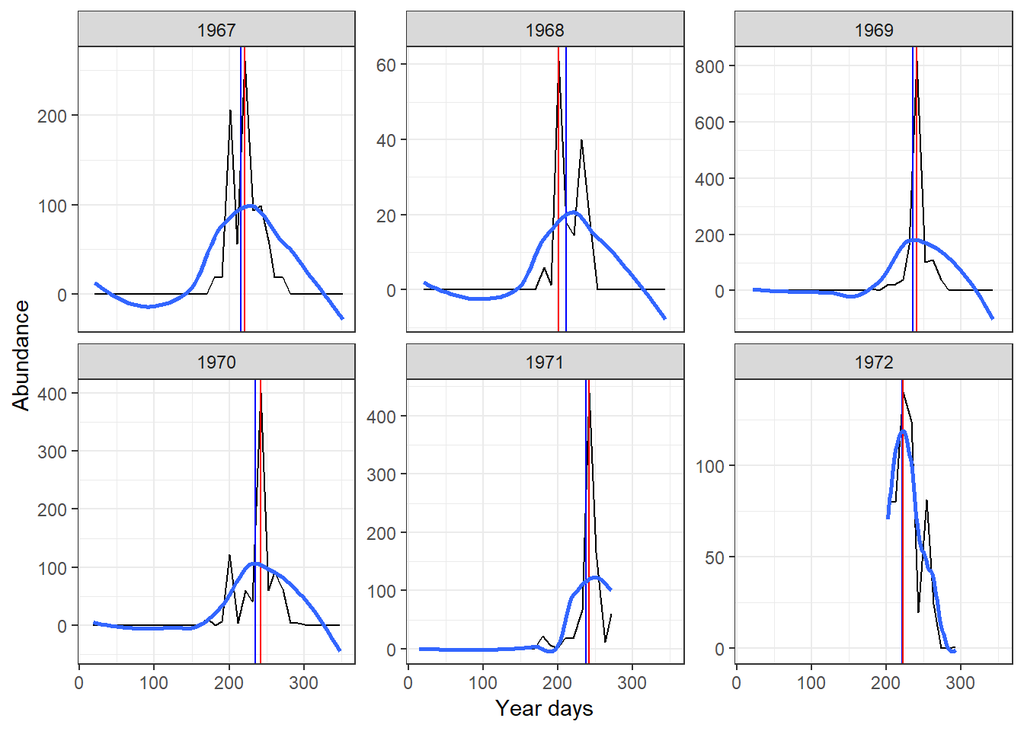

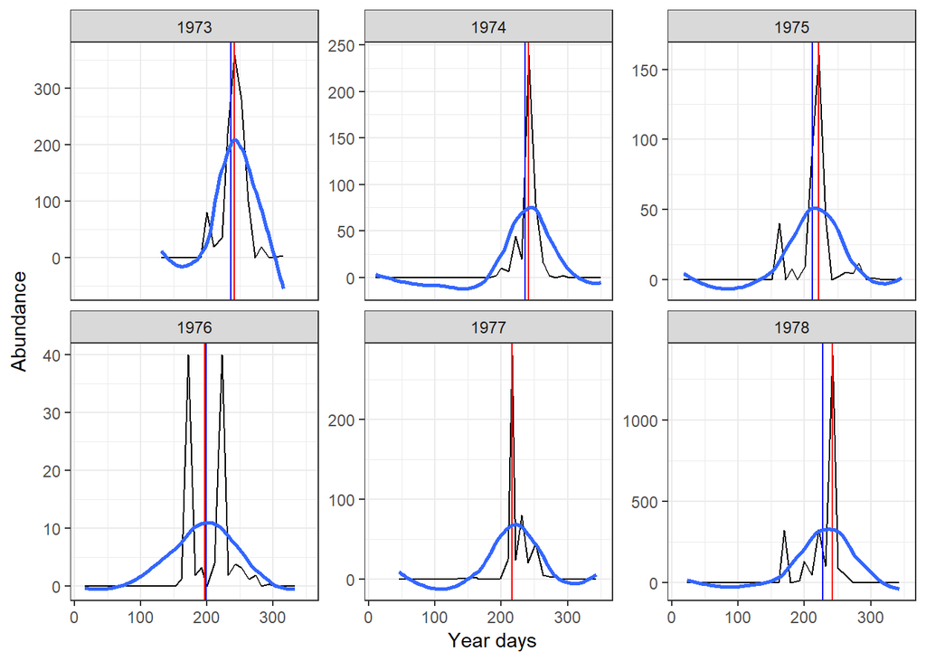

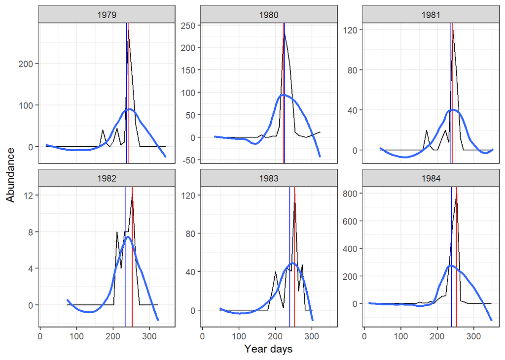

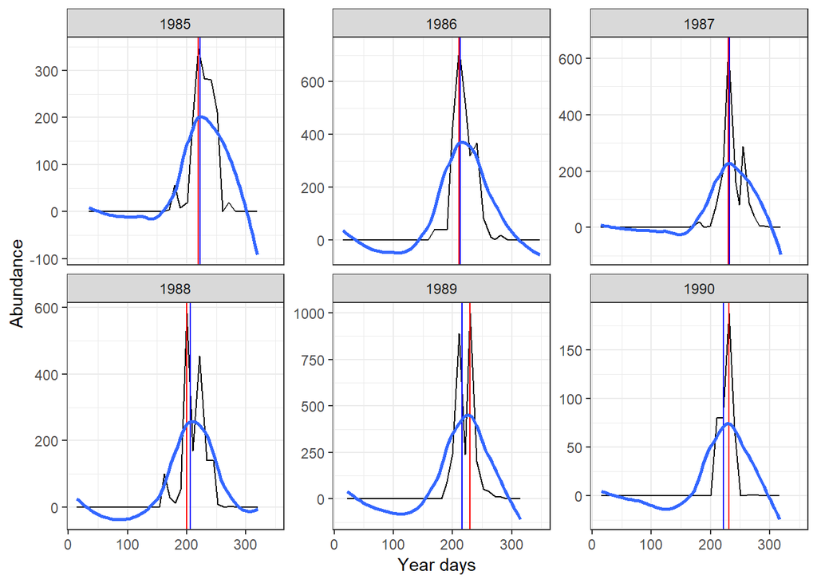

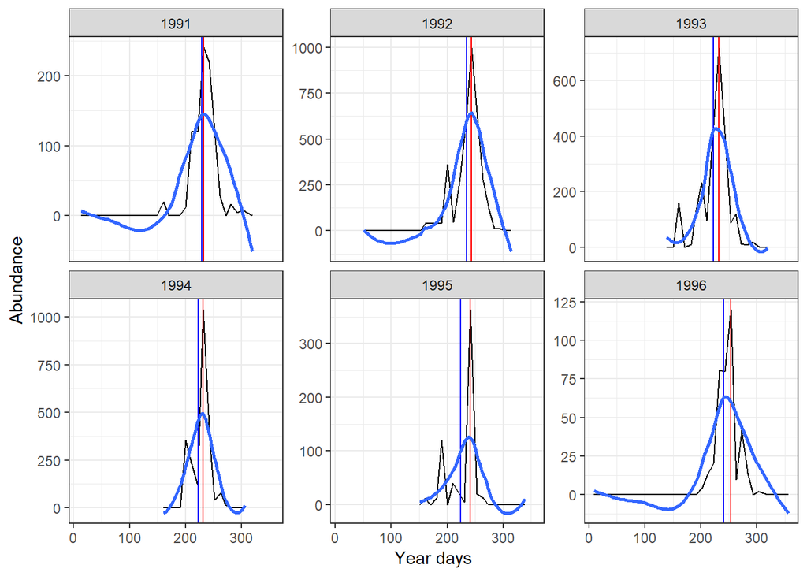

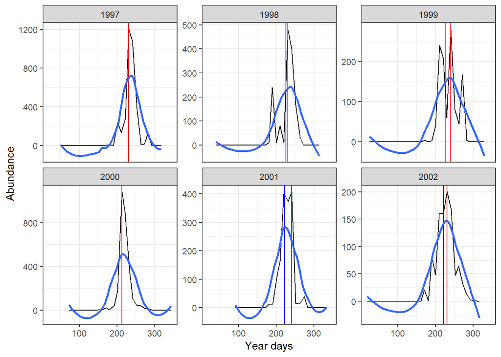

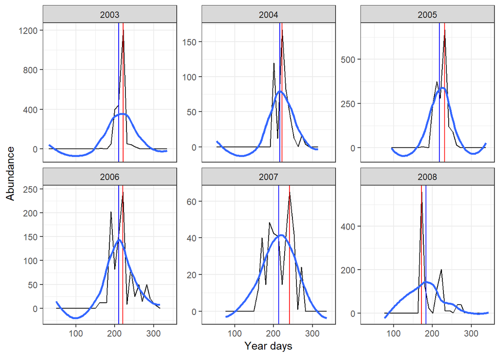

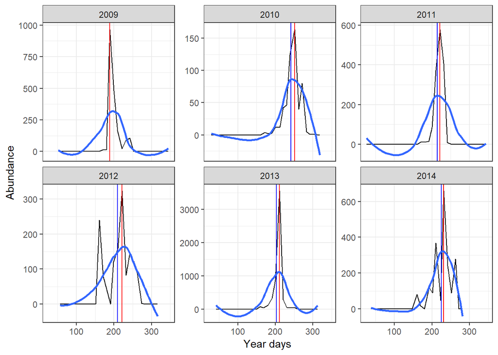

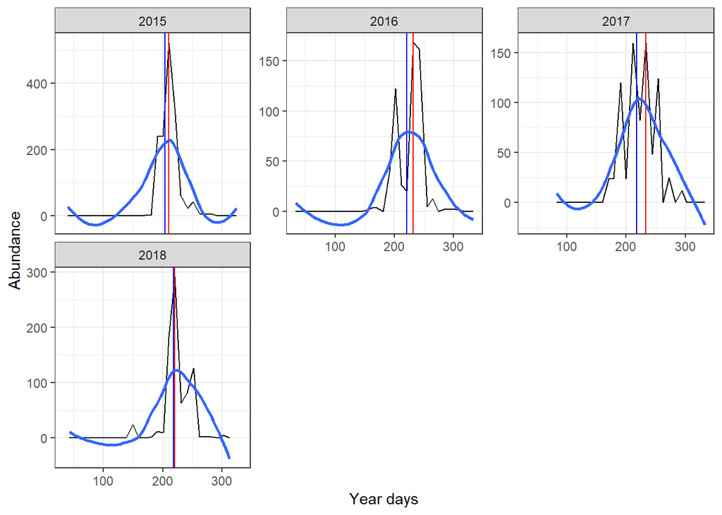

## Динамика Temora

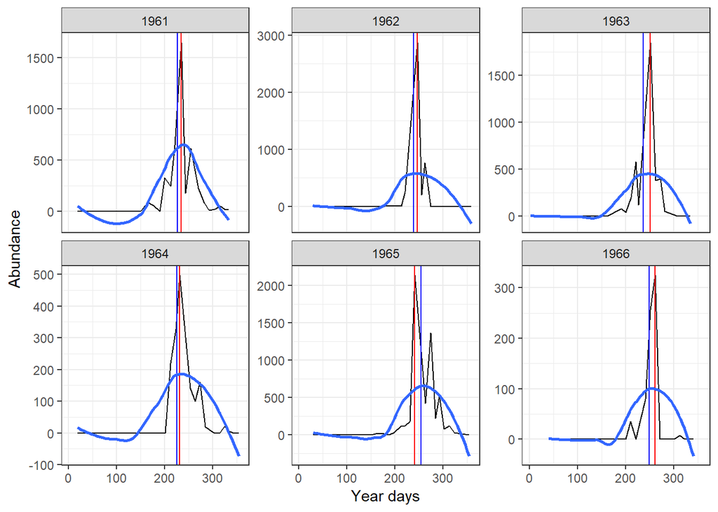

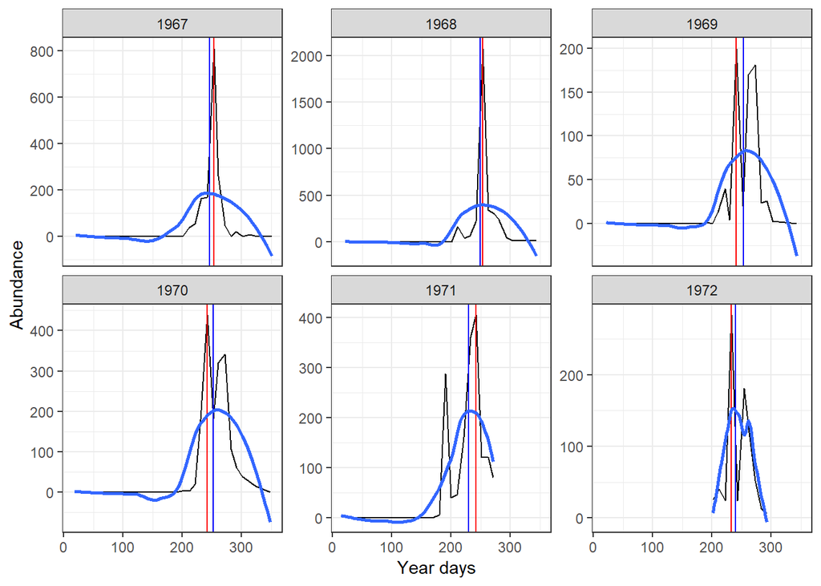

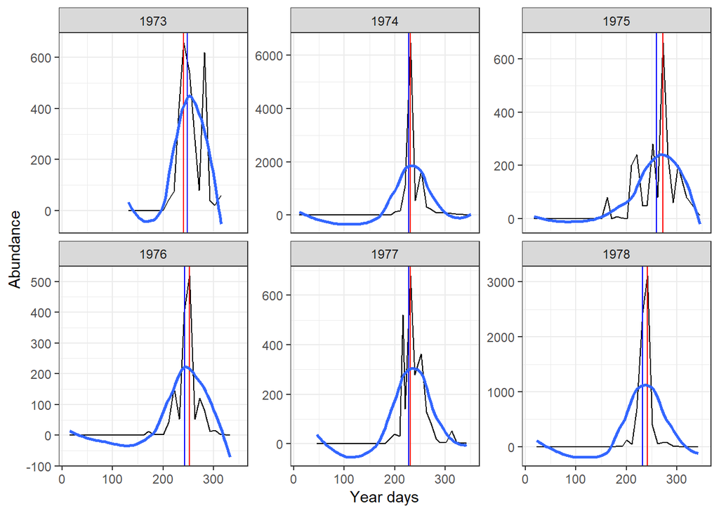

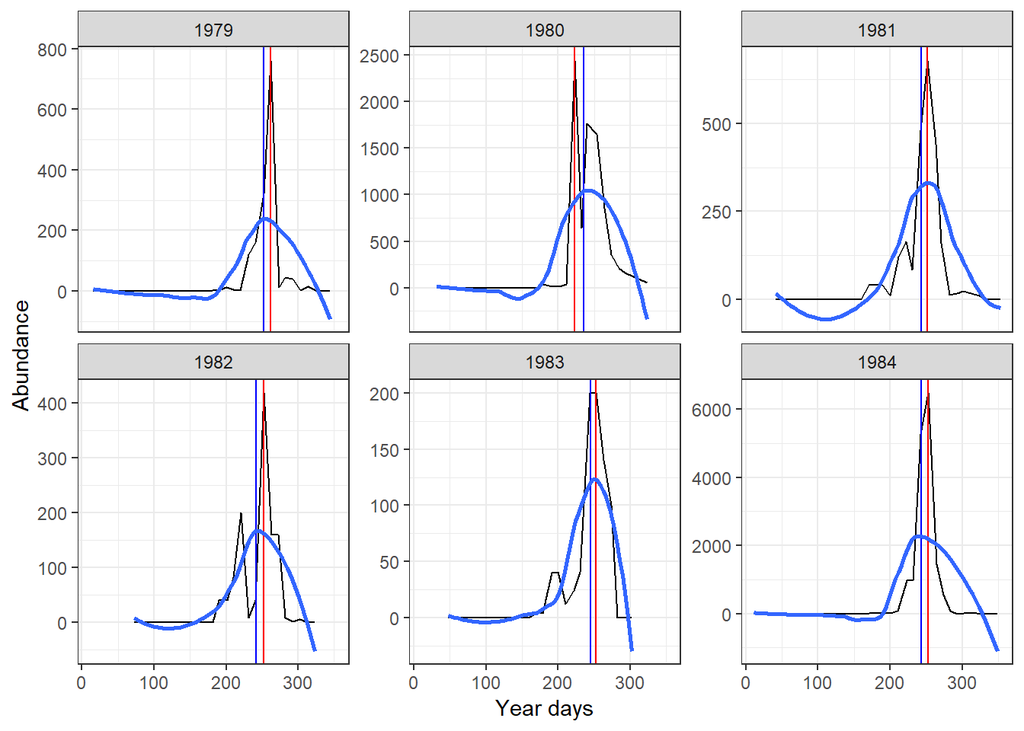

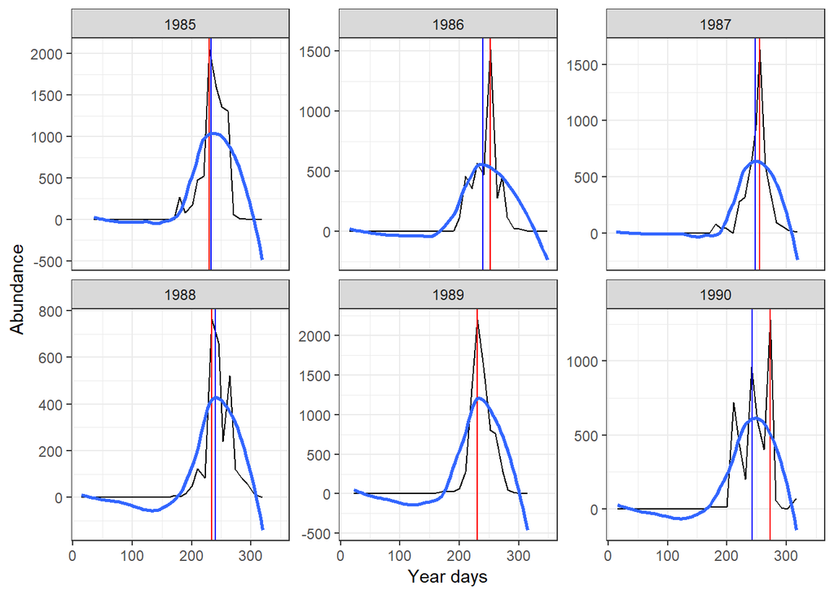

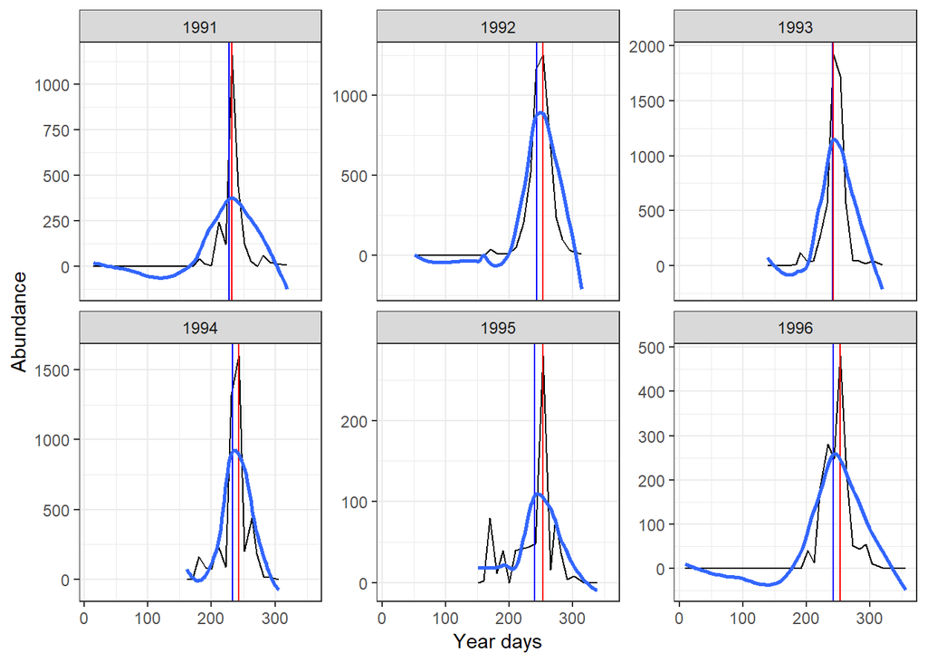

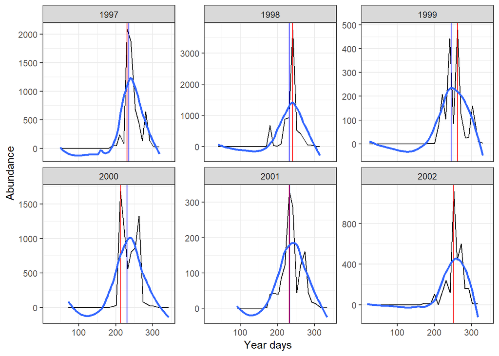

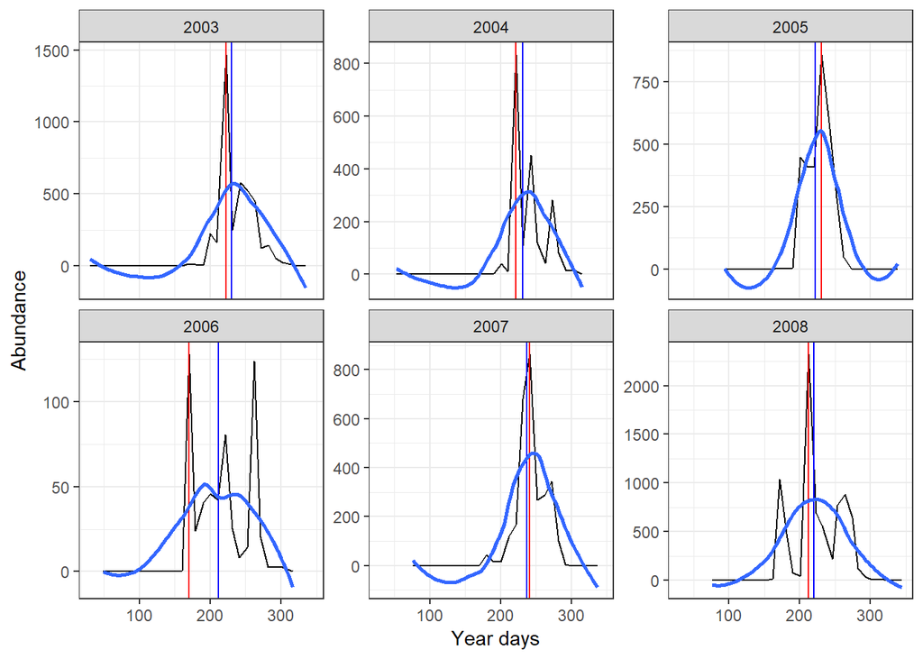

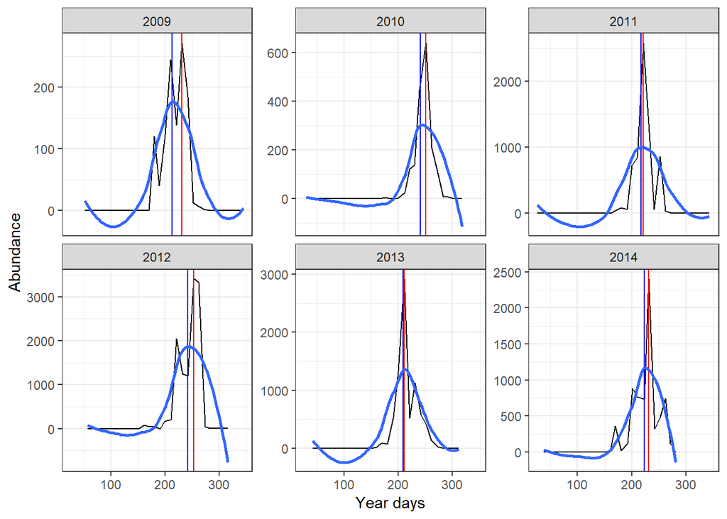

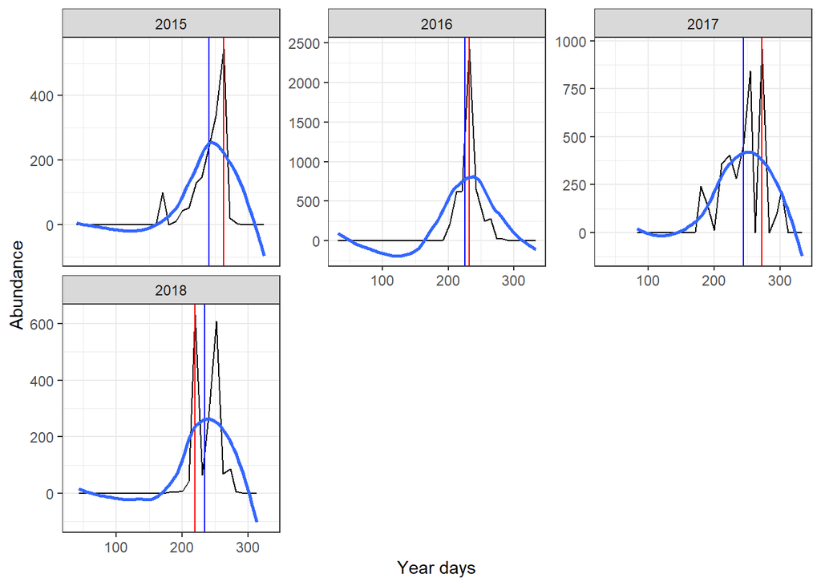

## Динамика Oithona

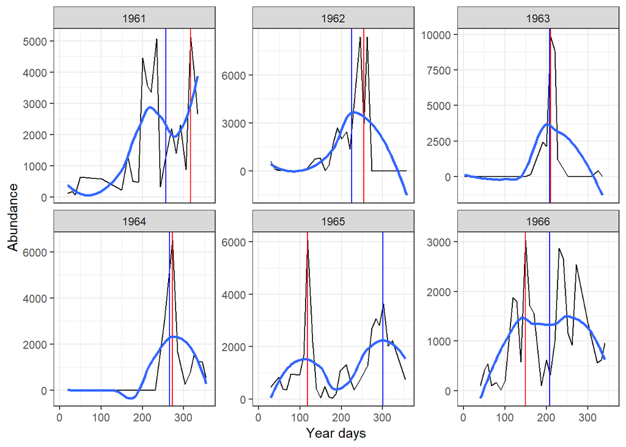

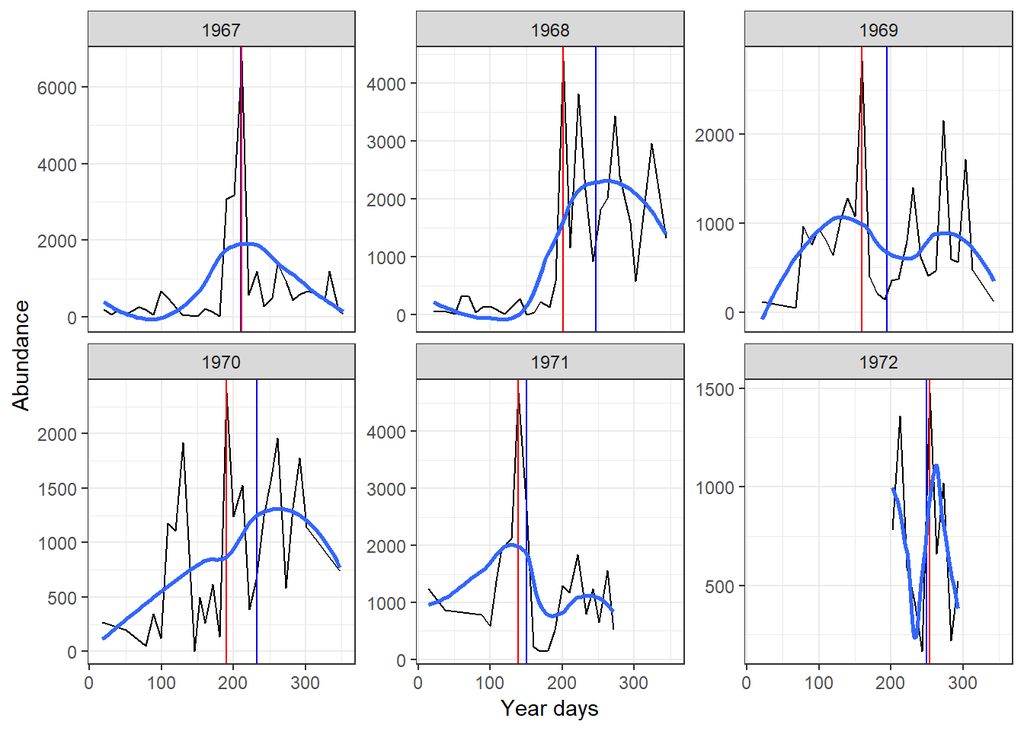

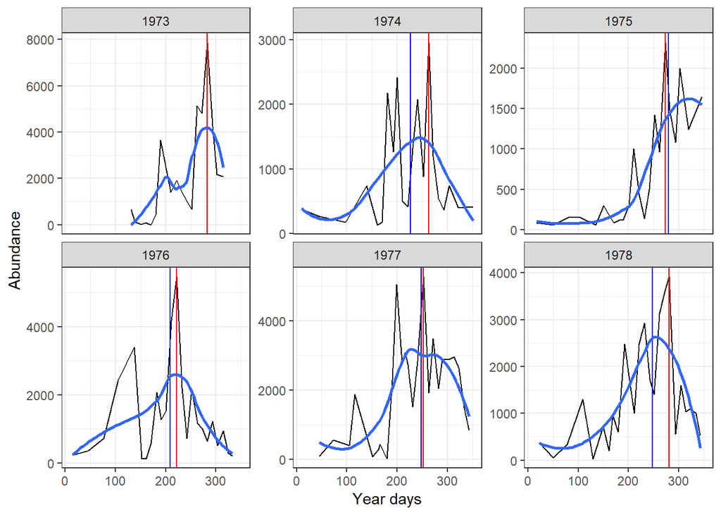

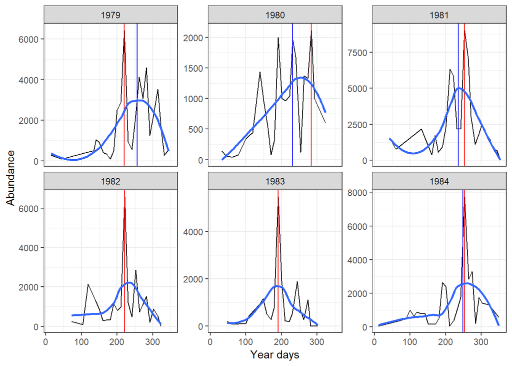

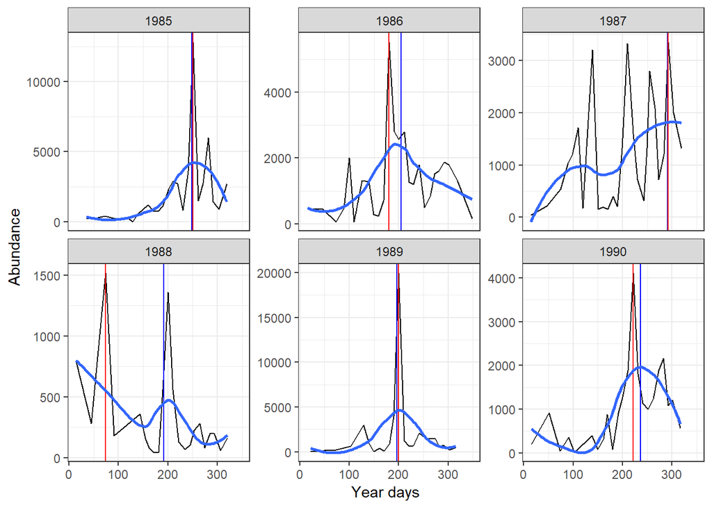

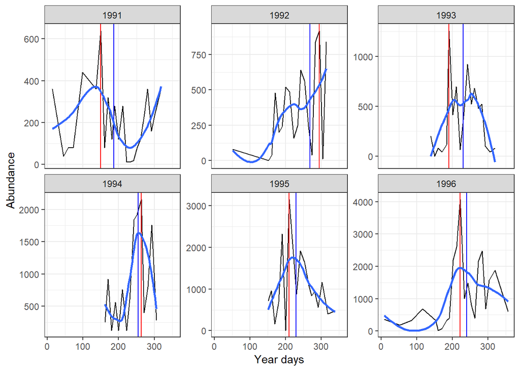

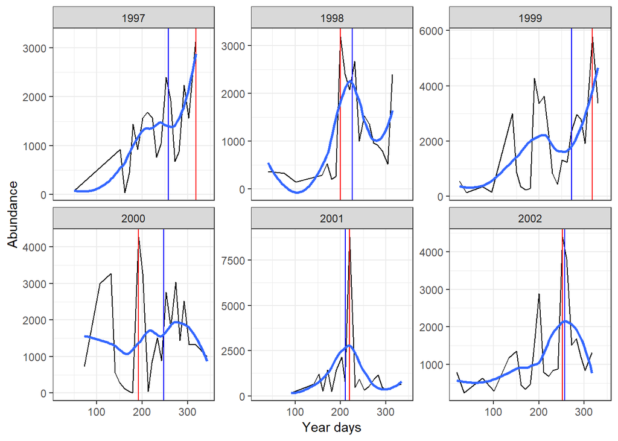

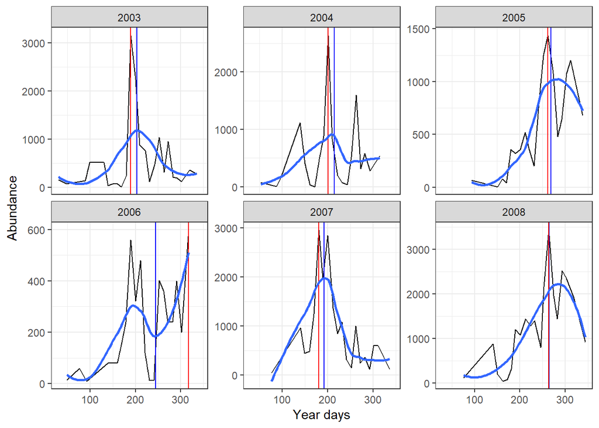

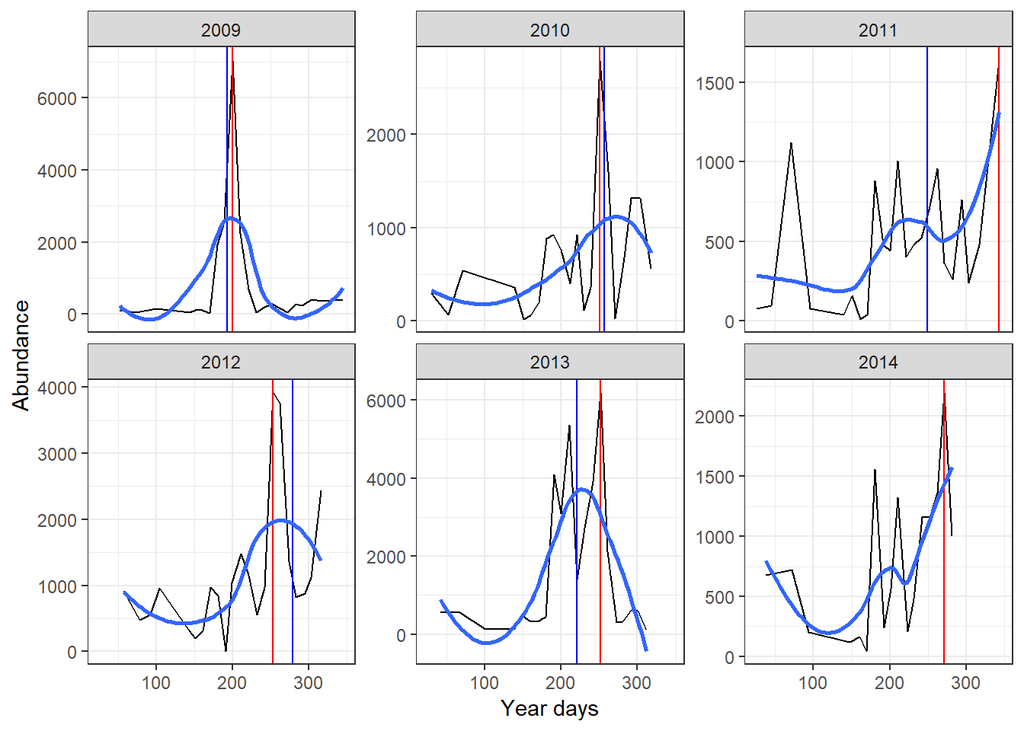

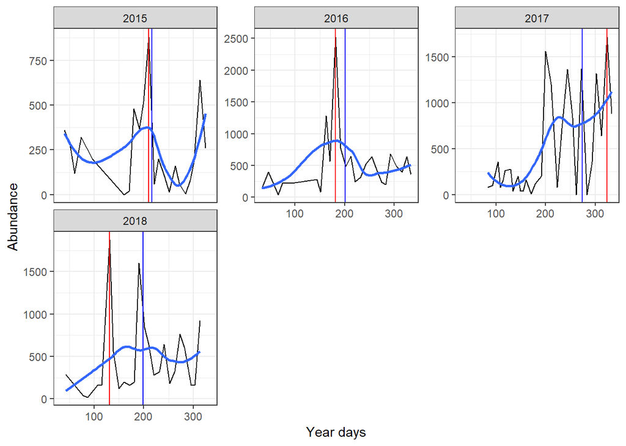

# Фенология видов

Если обобщить все данные, то наблюдается достаточно явная картина разделения сезонных показателей между видами.

Даты пиков расходятся у разных видов.

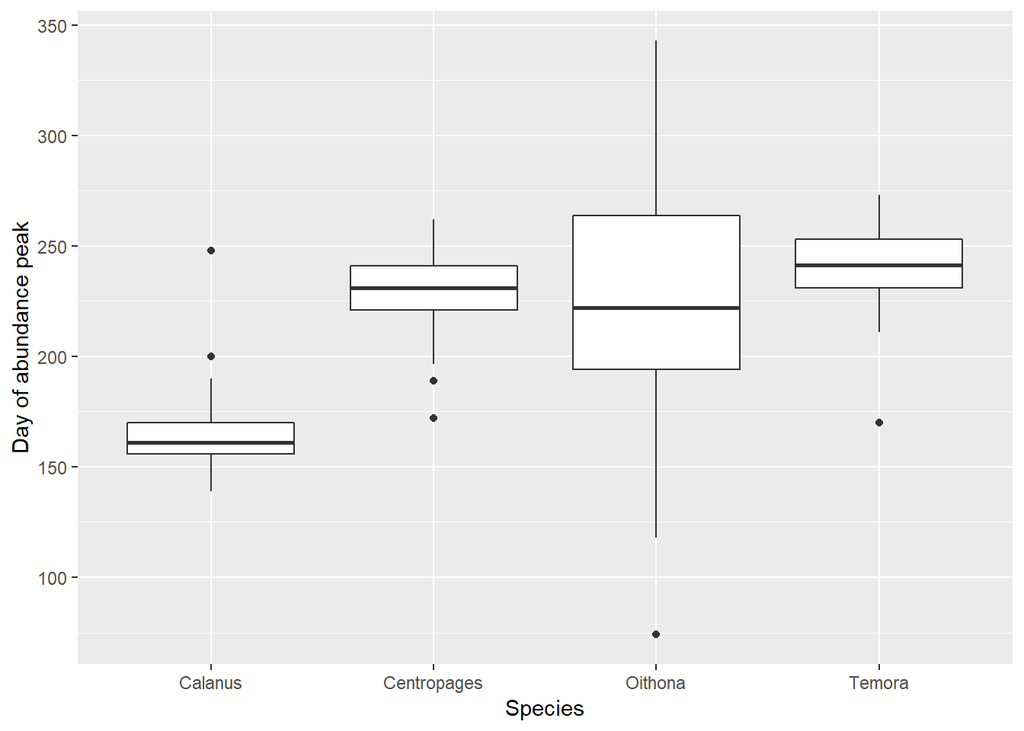

А вот так расходятся даты начала появления видов в точке наблюдения

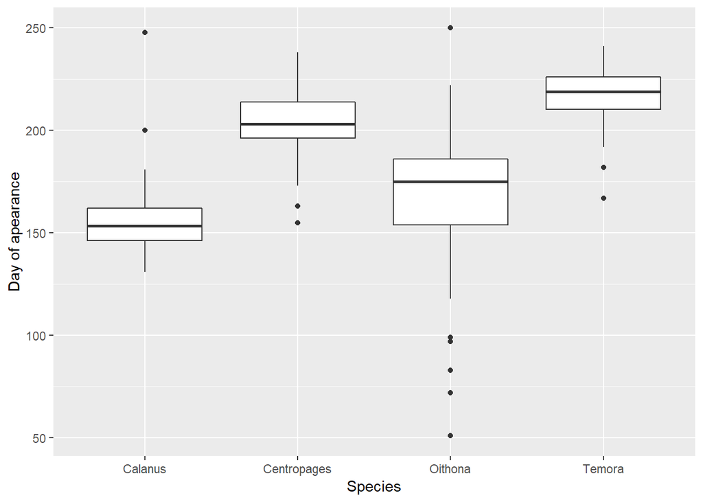

Видимо, это хорошо уже известно и описано, что *Calanus* начинает “вегетировать” раньше всех, потом в планктоне появляется *Oithona*. Самые поздние виды – *Temora* и *Centropages*.

# Часть 2. Динамика фенологических параметров

# Собственно вопросы исследования

Итого. Это все была подготовка к анализу. Далее будем использовать фенологические матрицы для ответа на ключевые вопросы исследования. Я их вижу так.

1. Присутствуют ли многолетние сдвиги в фенологических показателях видов.
2. Какие из параметров среды могут быть ответственны за наблюдаемые изменения.

# Сдвиги в фенологии.

Для выявления сдвигов в фенологических параметрах предлагается такой подход.

1. Формируем тренд-матрицу – это просто ряд от 1961 до 2018.
2. Для этой тренд-матрицы находим матрицу евклидовых расстояний между годами.
3. Строим общую фенологическую матрицу для всех видов.
4. Строим матрицу евклидовых расстояний между годами на основе этой матрицы.
5. С помощью теста Мантела оцениваем совпадение фенологической матрицы и тренд-матрицы.

```
##
## Mantel statistic based on Pearson's product-moment correlation
##
## Call:
## mantel(xdis = phen_dist, ydis = trend_dist, permutations = 9999)
##
## Mantel statistic r: 0.1018
##       Significance: 0.0289
##
## Upper quantiles of permutations (null model):
##    90%    95%  97.5%    99%
## 0.0669 0.0868 0.1056 0.1253
## Permutation: free
## Number of permutations: 9999
```

Этот результат говорит о том, что существуют многолетние смещения фенологических показателей в целом для всего сообщества копепод.

Этот анализ можно проделать и для каждого вида в отдельности.

## Для Calanus

```
##
## Mantel statistic based on Pearson's product-moment correlation
##
## Call:
## mantel(xdis = dist_calanus, ydis = trend_dist, permutations = 9999)
##
## Mantel statistic r: 0.1076
##       Significance: 0.0306
##
## Upper quantiles of permutations (null model):
##    90%    95%  97.5%    99%
## 0.0721 0.0929 0.1129 0.1325
## Permutation: free
## Number of permutations: 9999
```

## Для Centropages

```
##
## Mantel statistic based on Pearson's product-moment correlation
##
## Call:
## mantel(xdis = dist_centropages, ydis = trend_dist, permutations = 9999)
##
## Mantel statistic r: 0.08882
##       Significance: 0.0415
##
## Upper quantiles of permutations (null model):
##    90%    95%  97.5%    99%
## 0.0635 0.0835 0.1020 0.1246
## Permutation: free
## Number of permutations: 9999
```

## Для Temora

```
##
## Mantel statistic based on Pearson's product-moment correlation
##
## Call:
## mantel(xdis = dist_temora, ydis = trend_dist, permutations = 9999)
##
## Mantel statistic r: 0.1291
##       Significance: 0.0089
##
## Upper quantiles of permutations (null model):
##    90%    95%  97.5%    99%
## 0.0686 0.0903 0.1069 0.1258
## Permutation: free
## Number of permutations: 9999
```

## Для Oithona

```
##
## Mantel statistic based on Pearson's product-moment correlation
##
## Call:
## mantel(xdis = dist_oithona, ydis = trend_dist, permutations = 9999)
##
## Mantel statistic r: 0.05616
##       Significance: 0.134
##
## Upper quantiles of permutations (null model):
##    90%    95%  97.5%    99%
## 0.0657 0.0855 0.1029 0.1232
## Permutation: free
## Number of permutations: 9999
```

Эти результаты говорят о том, что сдвиги видны у всех, кроме *Oithona*, у которой, видимо, это не читается из-за сильно размытой сезонности.

Таким образом, гипотеза о сдвиге фенологических параметров подтверждается.

Для ответа на вопрос **куда** сдвигаются даты желательно отойти от многомерной оценки фенологии и ввести какую-то одну характеристику. Назовем ее “*фенологический индекс*”. Это просто средняя дата всех четырех ключевых событий (1. Наблюдаемый пик численности в точке наблюдения; 2. Появление в точке наблюдения; 3. Исчезновение из точки наблюдения; 4. Ожидаемый пик численности в точке наблюдения).

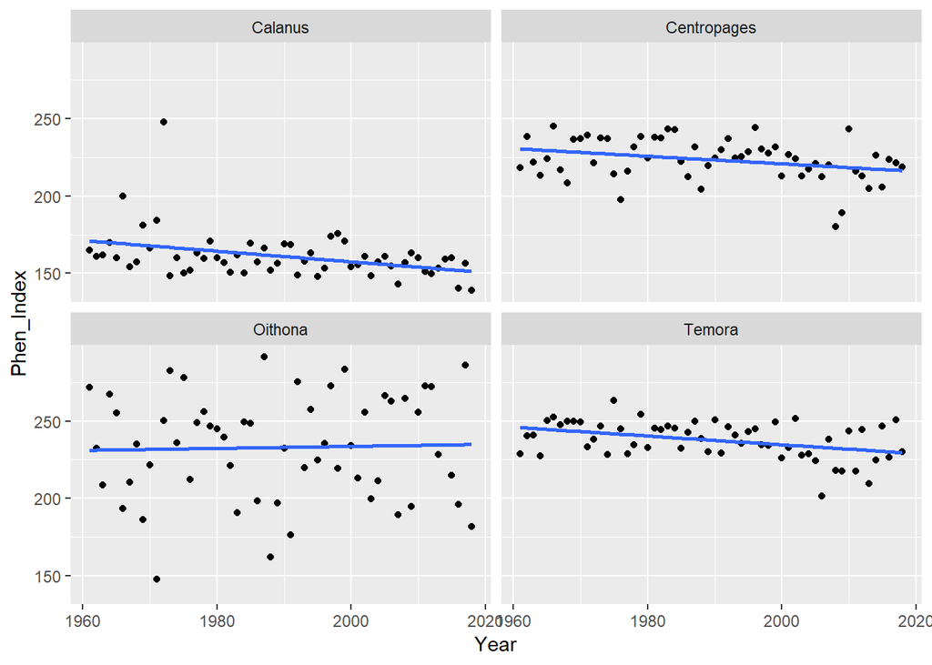

Эта картинка показывает, что в среднем даты ключевых событий смещаются на более ранние сроки.

## Какой параметр среды отвечает за наблюдаемые сдвиги?

Для этого наиболее подходящим, на мой взгляд, является процедура BIO-ENV.

```
## Studying 94183 of 524287 possible subsets (this may take time...)
```

```
##
## Call:
## bioenv(comm = phenol, env = env2, index = "euclidean", upto = 7,      partial = trend_dist)
##
## Subset of environmental variables with best correlation to community data.
##
## Correlations:    spearman
## Dissimilarities: euclidean
## Metric:          euclidean
##
## Best model has 4 parameters (max. 7 allowed):
## t_4 S_Sep Ice_thick_K Su_end_1
## with correlation  0.2088635
```

Таким образом, мы видим, что фенологическая матрица наилучшим образом сопряжена с небольшим набором средовых параметров. Согласно этому анализу, это дата, когда температура воды превышает 4 градуса, соленость в сентябре, толщина льда и дата окончания лета в прошлом году.

**НО! здесь есть масса нюансов, о которых надо говорить очно.**